# R-Based Forecasting Project: Construction Cost Index (2015=100)

Nazlı Pirim - 138722015

2026-05-28

## 1. Project Overview

This project forecasts the Construction Cost Index (2015=100) published by TurkStat (TÜİK) using monthly time series data accessed directly through the `tuikr` R package. The forecast target is February 2026, the next period after the latest available observation (January 2026).

## 2. Data Access via tuikr

```r
library(tuikr)
library(httr)
library(readxl)
library(dplyr)
library(tidyr)
library(ggplot2)
library(scales)

tables_price <- statistical_tables(theme = "6")

url_cci <- tables_price$table_url[
  tables_price$table_name == "Construction Cost Index (2015=100) and Rate of Change "]

response_cci <- GET(
  url_cci,
  add_headers(
    "User-Agent" = "Mozilla/5.0 (Windows NT 10.0; Win64; x64) AppleWebKit/537.36",
    "Accept"     = "application/json, text/plain, */*",
    "Referer"    = "https://veriportali.tuik.gov.tr/"
  )
)

cat("HTTP Status:", status_code(response_cci), "\n")
```

```
## HTTP Status: 200
```

```r
cat("Data access date:", format(Sys.time(), "%Y-%m-%d"), "\n")
```

```
## Data access date: 2026-05-28
```

```r
raw_cci <- content(response_cci, as = "raw")
tmp_cci <- tempfile(fileext = ".xls")
writeBin(raw_cci, tmp_cci)
df_cci  <- read_excel(tmp_cci)
```

## 3. Data Preparation

```r
colnames(df_cci) <- c("year","Jan","Feb","Mar","Apr","May","Jun",
                       "Jul","Aug","Sep","Oct","Nov","Dec")

df_index <- df_cci[6:17, ]

df_long <- df_index %>%
  mutate(year = as.integer(year)) %>%
  pivot_longer(cols = Jan:Dec, names_to = "month", values_to = "index") %>%
  mutate(
    month_num = match(month, c("Jan","Feb","Mar","Apr","May","Jun",
                                "Jul","Aug","Sep","Oct","Nov","Dec")),
    index = as.numeric(index)
  ) %>%
  filter(!is.na(index)) %>%
  arrange(year, month_num)

ts_cci <- ts(df_long$index, start = c(2015, 1), frequency = 12)

cat("Latest available observation: 2026 January\n")
```

```
## Latest available observation: 2026 January
```

```r
cat("Forecast target period: 2026 February\n")
```

```
## Forecast target period: 2026 February
```

```r
cat("Number of observations:", nrow(df_long), "\n")
```

```
## Number of observations: 133
```

## 4. Exploratory Time Series Analysis

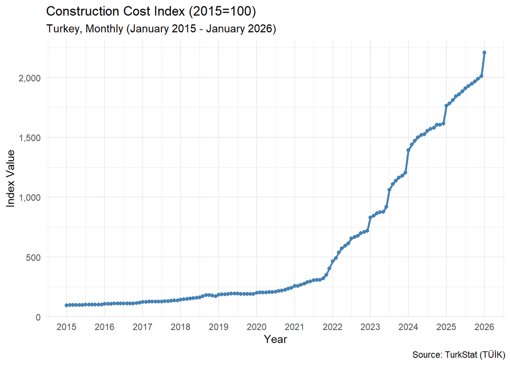

```r
plot_data <- data.frame(
  date  = as.numeric(time(ts_cci)),
  index = as.numeric(ts_cci)
)

ggplot(plot_data, aes(x = date, y = index)) +
  geom_line(color = "steelblue", linewidth = 1) +
  geom_point(color = "steelblue", size = 1.5) +
  labs(
    title    = "Construction Cost Index (2015=100)",
    subtitle = "Turkey, Monthly (January 2015 - January 2026)",
    x = "Year", y = "Index Value",
    caption  = "Source: TurkStat (TÜİK)"
  ) +
  theme_minimal() +
  scale_y_continuous(labels = comma) +
  scale_x_continuous(breaks = 2015:2026)
```

The series shows a strong upward trend, especially from 2021 onward due to high inflation in Turkey. Seasonality is weak relative to the dominant trend. No missing values detected.

## 5. Naive Forecasting

```r
naive_forecast <- as.numeric(tail(ts_cci, 1))
naive_fitted   <- c(NA, as.numeric(ts_cci[-length(ts_cci)]))
naive_errors   <- as.numeric(ts_cci) - naive_fitted

naive_bias <- mean(naive_errors, na.rm = TRUE)
naive_mad  <- mean(abs(naive_errors), na.rm = TRUE)
naive_mse  <- mean(naive_errors^2, na.rm = TRUE)
naive_mape <- mean(abs(naive_errors / as.numeric(ts_cci)) * 100, na.rm = TRUE)
naive_rsfe <- sum(naive_errors, na.rm = TRUE)
naive_ts   <- naive_rsfe / naive_mad

cat("Naive Forecast Feb 2026:", round(naive_forecast, 2), "\n")
```

```
## Naive Forecast Feb 2026: 2210.24
```

```r
cat("Bias:", round(naive_bias, 2), "| MAD:", round(naive_mad, 2),
    "| MSE:", round(naive_mse, 2), "| MAPE:", round(naive_mape, 2), "%\n")
```

```
## Bias: 16.01 | MAD: 16.27 | MSE: 1253.79 | MAPE: 2.45 %
```

```r
cat("RSFE:", round(naive_rsfe, 2), "| Tracking Signal:", round(naive_ts, 2), "\n")
```

```
## RSFE: 2113.11 | Tracking Signal: 129.87
```

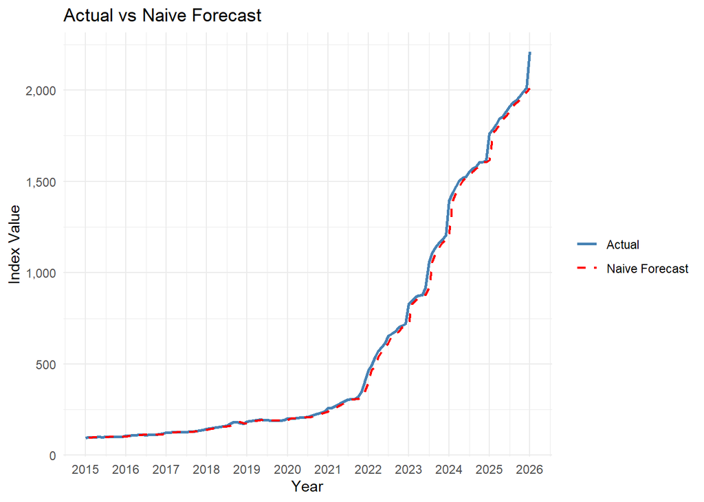

```r
naive_df <- data.frame(
  date   = as.numeric(time(ts_cci)),
  actual = as.numeric(ts_cci),
  fitted = naive_fitted
)

ggplot(naive_df, aes(x = date)) +
  geom_line(aes(y = actual, color = "Actual"), linewidth = 1) +
  geom_line(aes(y = fitted, color = "Naive Forecast"),
            linewidth = 0.8, linetype = "dashed", na.rm = TRUE) +
  scale_color_manual(values = c("Actual" = "steelblue",
                                 "Naive Forecast" = "red")) +
  labs(title = "Actual vs Naive Forecast", x = "Year",
       y = "Index Value", color = "") +
  theme_minimal() +
  scale_y_continuous(labels = comma) +
  scale_x_continuous(breaks = 2015:2026)
```

## 6. Moving Average

```r
window     <- 3
ma_fitted  <- as.numeric(stats::filter(ts_cci, rep(1/window, window), sides = 1))
ma_forecast <- mean(tail(as.numeric(ts_cci), window))

ma_errors <- as.numeric(ts_cci) - ma_fitted
ma_bias <- mean(ma_errors, na.rm = TRUE)
ma_mad  <- mean(abs(ma_errors), na.rm = TRUE)
ma_mse  <- mean(ma_errors^2, na.rm = TRUE)
ma_mape <- mean(abs(ma_errors / as.numeric(ts_cci)) * 100, na.rm = TRUE)
ma_rsfe <- sum(ma_errors, na.rm = TRUE)
ma_ts   <- ma_rsfe / ma_mad

cat("MA(3) Forecast Feb 2026:", round(ma_forecast, 2), "\n")
```

```
## MA(3) Forecast Feb 2026: 2070.19
```

```r
cat("Bias:", round(ma_bias, 2), "| MAD:", round(ma_mad, 2),
    "| MSE:", round(ma_mse, 2), "| MAPE:", round(ma_mape, 2), "%\n")
```

```
## Bias: 15.62 | MAD: 15.83 | MSE: 889.04 | MAPE: 2.38 %
```

```r
cat("RSFE:", round(ma_rsfe, 2), "| Tracking Signal:", round(ma_ts, 2), "\n")
```

```
## RSFE: 2046.6 | Tracking Signal: 129.28
```

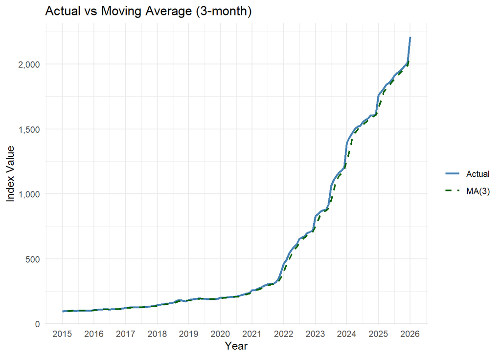

```r
ma_df <- data.frame(
  date   = as.numeric(time(ts_cci)),
  actual = as.numeric(ts_cci),
  fitted = ma_fitted
)

ggplot(ma_df, aes(x = date)) +
  geom_line(aes(y = actual, color = "Actual"), linewidth = 1) +
  geom_line(aes(y = fitted, color = "MA(3)"),
            linewidth = 0.8, linetype = "dashed", na.rm = TRUE) +
  scale_color_manual(values = c("Actual" = "steelblue", "MA(3)" = "darkgreen")) +
  labs(title = "Actual vs Moving Average (3-month)", x = "Year",
       y = "Index Value", color = "") +
  theme_minimal() +
  scale_y_continuous(labels = comma) +
  scale_x_continuous(breaks = 2015:2026)
```

## 7. Weighted Moving Average

```r
w <- c(0.1, 0.3, 0.6)
n <- length(ts_cci)
wma_fitted <- rep(NA, n)
for (i in 3:n) {
  wma_fitted[i] <- sum(w * as.numeric(ts_cci)[(i-2):i])
}
wma_forecast <- sum(w * tail(as.numeric(ts_cci), 3))

wma_errors <- as.numeric(ts_cci) - wma_fitted
wma_bias <- mean(wma_errors, na.rm = TRUE)
wma_mad  <- mean(abs(wma_errors), na.rm = TRUE)
wma_mse  <- mean(wma_errors^2, na.rm = TRUE)
wma_mape <- mean(abs(wma_errors / as.numeric(ts_cci)) * 100, na.rm = TRUE)
wma_rsfe <- sum(wma_errors, na.rm = TRUE)
wma_ts   <- wma_rsfe / wma_mad

cat("WMA Forecast Feb 2026:", round(wma_forecast, 2), "\n")
```

```
## WMA Forecast Feb 2026: 2128.53
```

```r
cat("Bias:", round(wma_bias, 2), "| MAD:", round(wma_mad, 2),
    "| MSE:", round(wma_mse, 2), "| MAPE:", round(wma_mape, 2), "%\n")
```

```
## Bias: 7.91 | MAD: 8.02 | MSE: 251.47 | MAPE: 1.2 %
```

```r
cat("RSFE:", round(wma_rsfe, 2), "| Tracking Signal:", round(wma_ts, 2), "\n")
```

```
## RSFE: 1036.5 | Tracking Signal: 129.18
```

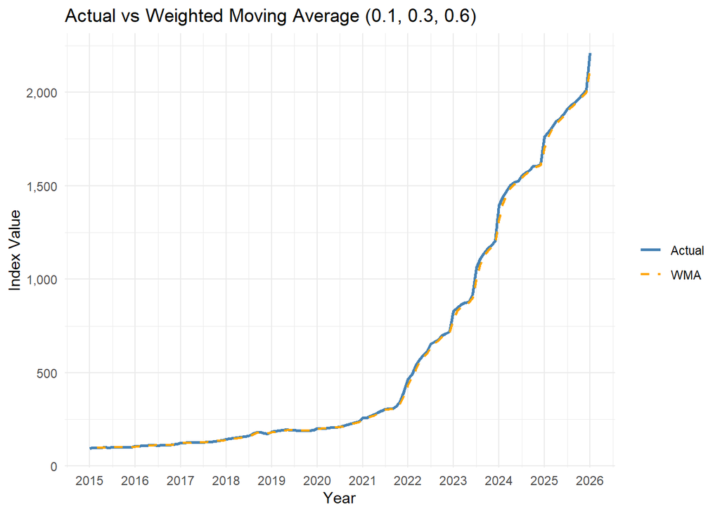

```r
wma_df <- data.frame(
  date   = as.numeric(time(ts_cci)),
  actual = as.numeric(ts_cci),
  fitted = wma_fitted
)

ggplot(wma_df, aes(x = date)) +
  geom_line(aes(y = actual, color = "Actual"), linewidth = 1) +
  geom_line(aes(y = fitted, color = "WMA"),
            linewidth = 0.8, linetype = "dashed", na.rm = TRUE) +
  scale_color_manual(values = c("Actual" = "steelblue", "WMA" = "orange")) +
  labs(title = "Actual vs Weighted Moving Average (0.1, 0.3, 0.6)",
       x = "Year", y = "Index Value", color = "") +
  theme_minimal() +
  scale_y_continuous(labels = comma) +
  scale_x_continuous(breaks = 2015:2026)
```

## 8. Exponential Smoothing

```r
library(forecast)

# Test alpha = 0.9 (high - suitable for trending series)
es_model <- ses(ts_cci, alpha = 0.9, h = 1)
es_forecast <- as.numeric(es_model$mean)
es_fitted <- as.numeric(es_model$fitted)

es_errors <- as.numeric(ts_cci) - es_fitted
es_bias <- mean(es_errors, na.rm = TRUE)
es_mad  <- mean(abs(es_errors), na.rm = TRUE)
es_mse  <- mean(es_errors^2, na.rm = TRUE)
es_mape <- mean(abs(es_errors / as.numeric(ts_cci)) * 100, na.rm = TRUE)
es_rsfe <- sum(es_errors, na.rm = TRUE)
es_ts   <- es_rsfe / es_mad

cat("Exponential Smoothing (alpha=0.9) Forecast Feb 2026:",
    round(es_forecast, 2), "\n")
```

```
## Exponential Smoothing (alpha=0.9) Forecast Feb 2026: 2190.14
```

```r
cat("Bias:", round(es_bias, 2), "| MAD:", round(es_mad, 2),
    "| MSE:", round(es_mse, 2), "| MAPE:", round(es_mape, 2), "%\n")
```

```
## Bias: 17.48 | MAD: 17.74 | MSE: 1361.45 | MAPE: 2.67 %
```

```r
cat("RSFE:", round(es_rsfe, 2), "| Tracking Signal:", round(es_ts, 2), "\n")
```

```
## RSFE: 2325.33 | Tracking Signal: 131.05
```

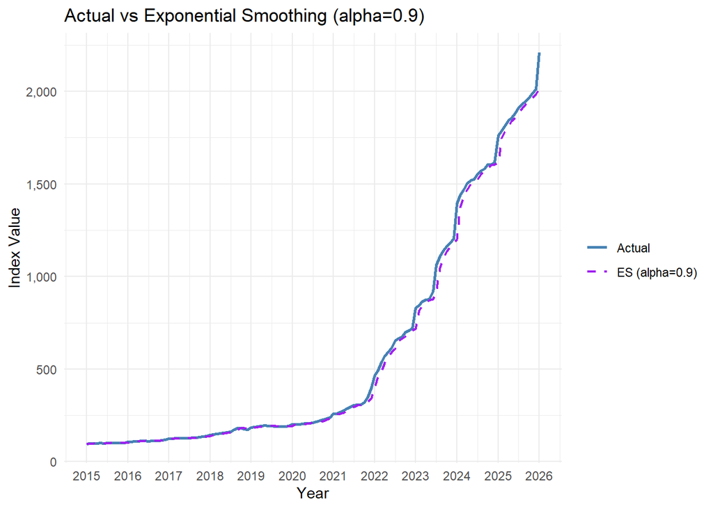

```r
es_df <- data.frame(
  date   = as.numeric(time(ts_cci)),
  actual = as.numeric(ts_cci),
  fitted = es_fitted
)

ggplot(es_df, aes(x = date)) +
  geom_line(aes(y = actual, color = "Actual"), linewidth = 1) +
  geom_line(aes(y = fitted, color = "ES (alpha=0.9)"),
            linewidth = 0.8, linetype = "dashed") +
  scale_color_manual(values = c("Actual" = "steelblue",
                                 "ES (alpha=0.9)" = "purple")) +
  labs(title = "Actual vs Exponential Smoothing (alpha=0.9)",
       x = "Year", y = "Index Value", color = "") +
  theme_minimal() +
  scale_y_continuous(labels = comma) +
  scale_x_continuous(breaks = 2015:2026)
```

## 9. Trend-Adjusted Exponential Smoothing (Holt’s Method)

```r
# Holt's method - suitable since series has strong trend
holt_model <- holt(ts_cci, alpha = 0.9, beta = 0.3, h = 1)
holt_forecast <- as.numeric(holt_model$mean)
holt_fitted <- as.numeric(holt_model$fitted)

holt_errors <- as.numeric(ts_cci) - holt_fitted
holt_bias <- mean(holt_errors, na.rm = TRUE)
holt_mad  <- mean(abs(holt_errors), na.rm = TRUE)
holt_mse  <- mean(holt_errors^2, na.rm = TRUE)
holt_mape <- mean(abs(holt_errors / as.numeric(ts_cci)) * 100, na.rm = TRUE)
holt_rsfe <- sum(holt_errors, na.rm = TRUE)
holt_ts   <- holt_rsfe / holt_mad

cat("Holt's Forecast Feb 2026:", round(holt_forecast, 2), "\n")
```

```
## Holt's Forecast Feb 2026: 2267.56
```

```r
cat("Bias:", round(holt_bias, 2), "| MAD:", round(holt_mad, 2),
    "| MSE:", round(holt_mse, 2), "| MAPE:", round(holt_mape, 2), "%\n")
```

```
## Bias: 1.86 | MAD: 12.29 | MSE: 885.62 | MAPE: 1.82 %
```

```r
cat("RSFE:", round(holt_rsfe, 2), "| Tracking Signal:", round(holt_ts, 2), "\n")
```

```
## RSFE: 247.88 | Tracking Signal: 20.17
```

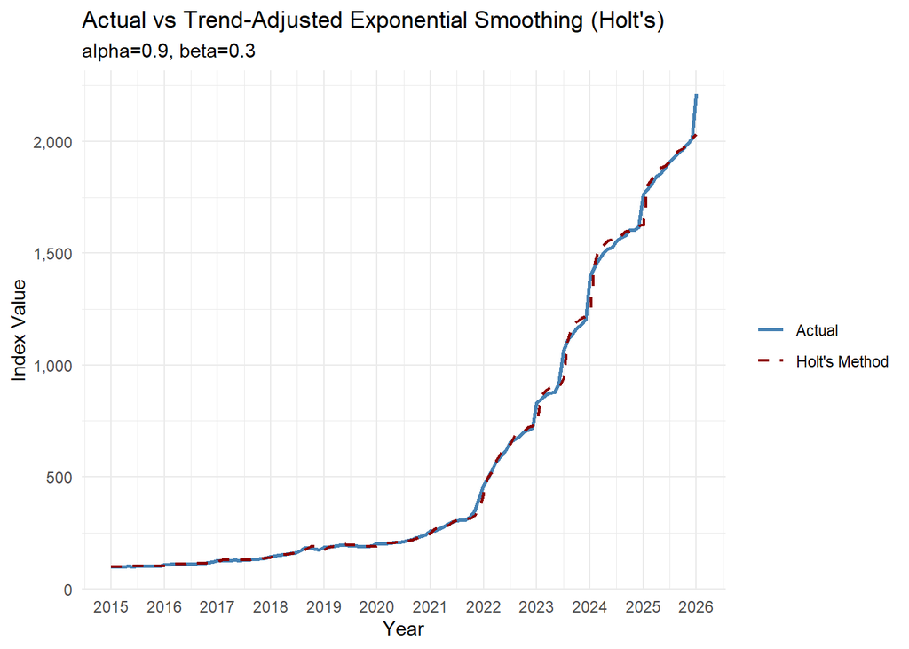

```r
holt_df <- data.frame(
  date   = as.numeric(time(ts_cci)),
  actual = as.numeric(ts_cci),
  fitted = holt_fitted
)

ggplot(holt_df, aes(x = date)) +
  geom_line(aes(y = actual, color = "Actual"), linewidth = 1) +
  geom_line(aes(y = fitted, color = "Holt's Method"),
            linewidth = 0.8, linetype = "dashed") +
  scale_color_manual(values = c("Actual" = "steelblue",
                                 "Holt's Method" = "darkred")) +
  labs(title = "Actual vs Trend-Adjusted Exponential Smoothing (Holt's)",
       subtitle = "alpha=0.9, beta=0.3",
       x = "Year", y = "Index Value", color = "") +
  theme_minimal() +
  scale_y_continuous(labels = comma) +
  scale_x_continuous(breaks = 2015:2026)
```

## 10. Linear Trend Projection

```r
# Create time index
t <- 1:length(ts_cci)
trend_model <- lm(as.numeric(ts_cci) ~ t)
summary(trend_model)
```

```
##
## Call:
## lm(formula = as.numeric(ts_cci) ~ t)
##
## Residuals:
##    Min     1Q Median     3Q    Max
## -470.1 -269.7  -14.2  286.8  700.1
##
## Coefficients:
##              Estimate Std. Error t value Pr(>|t|)
## (Intercept) -361.5815    53.3240  -6.781  3.7e-10 ***
## t             14.0731     0.6905  20.380  < 2e-16 ***
## ---
## Signif. codes:  0 '***' 0.001 '**' 0.01 '*' 0.05 '.' 0.1 ' ' 1
##
## Residual standard error: 305.7 on 131 degrees of freedom
## Multiple R-squared:  0.7602, Adjusted R-squared:  0.7584
## F-statistic: 415.3 on 1 and 131 DF,  p-value: < 2.2e-16
```

```r
trend_fitted <- as.numeric(fitted(trend_model))
trend_forecast <- predict(trend_model, newdata = data.frame(t = length(ts_cci) + 1))

trend_errors <- as.numeric(ts_cci) - trend_fitted
trend_bias <- mean(trend_errors)
trend_mad  <- mean(abs(trend_errors))
trend_mse  <- mean(trend_errors^2)
trend_mape <- mean(abs(trend_errors / as.numeric(ts_cci)) * 100)
trend_rsfe <- sum(trend_errors)
trend_ts   <- trend_rsfe / trend_mad

cat("Linear Trend Forecast Feb 2026:", round(trend_forecast, 2), "\n")
```

```
## Linear Trend Forecast Feb 2026: 1524.21
```

```r
cat("Intercept:", round(coef(trend_model)[1], 2),
    "| Slope:", round(coef(trend_model)[2], 2), "\n")
```

```
## Intercept: -361.58 | Slope: 14.07
```

```r
cat("Bias:", round(trend_bias, 2), "| MAD:", round(trend_mad, 2),
    "| MSE:", round(trend_mse, 2), "| MAPE:", round(trend_mape, 2), "%\n")
```

```
## Bias: 0 | MAD: 265.31 | MSE: 92076.66 | MAPE: 107.24 %
```

```r
cat("RSFE:", round(trend_rsfe, 2), "| Tracking Signal:", round(trend_ts, 2), "\n")
```

```
## RSFE: 0 | Tracking Signal: 0
```

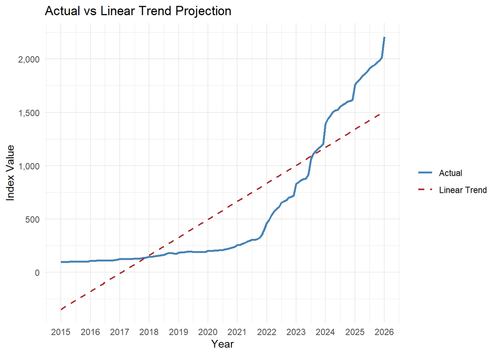

```r
trend_df <- data.frame(
  date   = as.numeric(time(ts_cci)),
  actual = as.numeric(ts_cci),
  fitted = trend_fitted
)

ggplot(trend_df, aes(x = date)) +
  geom_line(aes(y = actual, color = "Actual"), linewidth = 1) +
  geom_line(aes(y = fitted, color = "Linear Trend"),
            linewidth = 0.8, linetype = "dashed") +
  scale_color_manual(values = c("Actual" = "steelblue",
                                 "Linear Trend" = "brown")) +
  labs(title = "Actual vs Linear Trend Projection",
       x = "Year", y = "Index Value", color = "") +
  theme_minimal() +
  scale_y_continuous(labels = comma) +
  scale_x_continuous(breaks = 2015:2026)
```

## 11. Seasonal Indices

```r
# Monthly seasonal indices
# Extract month from time series
months <- cycle(ts_cci)
years  <- floor(time(ts_cci))

# Calculate seasonal indices
monthly_means <- tapply(as.numeric(ts_cci), months, mean)
overall_mean  <- mean(as.numeric(ts_cci))
seasonal_idx  <- monthly_means / overall_mean

cat("Seasonal Indices by Month:\n")
```

```
## Seasonal Indices by Month:
```

```r
month_names <- c("Jan","Feb","Mar","Apr","May","Jun",
                  "Jul","Aug","Sep","Oct","Nov","Dec")
for(i in 1:12) {
  cat(month_names[i], ":", round(seasonal_idx[i], 4), "\n")
}
```

```
## Jan : 1.1152
## Feb : 0.8893
## Mar : 0.9113
## Apr : 0.9305
## May : 0.9439
## Jun : 0.9599
## Jul : 0.9993
## Aug : 1.0181
## Sep : 1.0307
## Oct : 1.0485
## Nov : 1.0611
## Dec : 1.0818
```

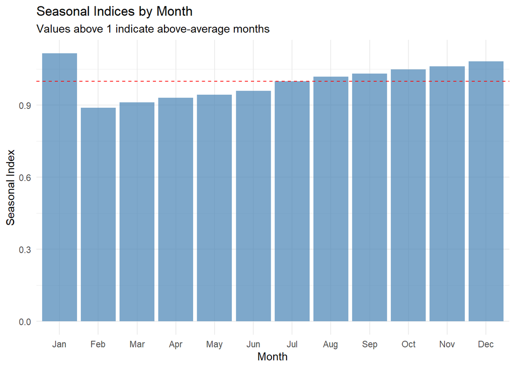

```r
# The series has a dominant trend; seasonal variation is minimal
# Deseasonalized values
deseasonalized <- as.numeric(ts_cci) / seasonal_idx[months]

# Seasonal indices plot
si_df <- data.frame(
  month = month_names,
  index = as.numeric(seasonal_idx)
)
si_df$month <- factor(si_df$month, levels = month_names)

ggplot(si_df, aes(x = month, y = index)) +
  geom_bar(stat = "identity", fill = "steelblue", alpha = 0.7) +
  geom_hline(yintercept = 1, linetype = "dashed", color = "red") +
  labs(title = "Seasonal Indices by Month",
       subtitle = "Values above 1 indicate above-average months",
       x = "Month", y = "Seasonal Index") +
  theme_minimal()
```

## 12. Additive Decomposition

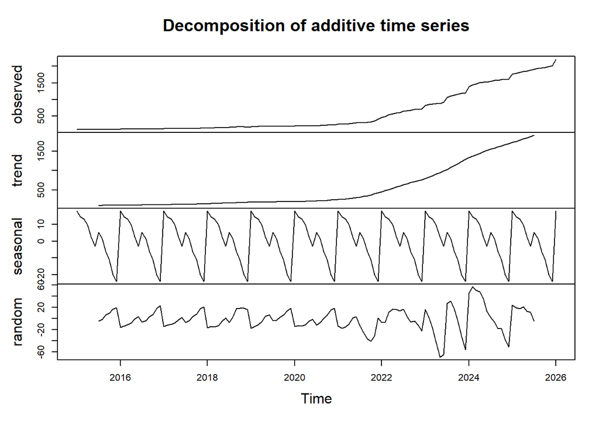

```r
# Additive decomposition
decomp_add <- decompose(ts_cci, type = "additive")

# Plot decomposition
plot(decomp_add)
```

```r
# Forecast using trend + seasonal
trend_comp    <- as.numeric(decomp_add$trend)
seasonal_comp <- as.numeric(decomp_add$seasonal)
random_comp   <- as.numeric(decomp_add$random)

# Fitted values
add_fitted <- trend_comp + seasonal_comp
add_errors <- as.numeric(ts_cci) - add_fitted
add_bias <- mean(add_errors, na.rm = TRUE)
add_mad  <- mean(abs(add_errors), na.rm = TRUE)
add_mse  <- mean(add_errors^2, na.rm = TRUE)
add_mape <- mean(abs(add_errors / as.numeric(ts_cci)) * 100, na.rm = TRUE)
add_rsfe <- sum(add_errors, na.rm = TRUE)
add_ts   <- add_rsfe / add_mad

cat("Additive Decomposition:\n")
```

```
## Additive Decomposition:
```

```r
cat("Bias:", round(add_bias, 2), "| MAD:", round(add_mad, 2),
    "| MSE:", round(add_mse, 2), "| MAPE:", round(add_mape, 2), "%\n")
```

```
## Bias: -1.16 | MAD: 15.44 | MSE: 433.04 | MAPE: 4.98 %
```

```r
cat("RSFE:", round(add_rsfe, 2), "| Tracking Signal:", round(add_ts, 2), "\n")
```

```
## RSFE: -139.79 | Tracking Signal: -9.05
```

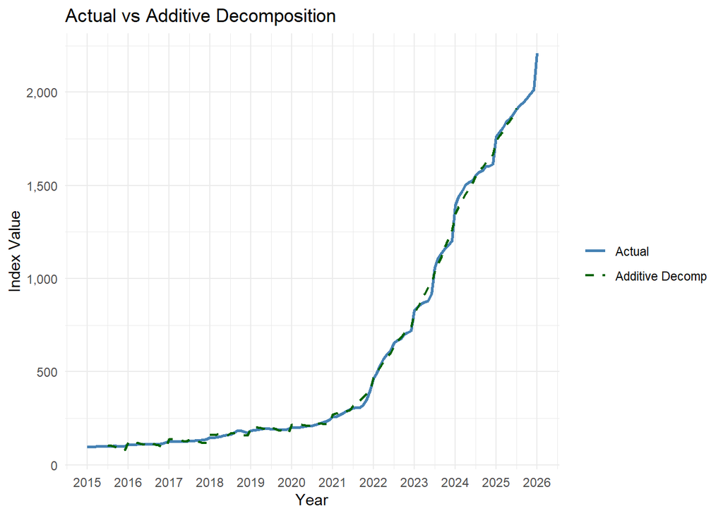

```r
add_df <- data.frame(
  date   = as.numeric(time(ts_cci)),
  actual = as.numeric(ts_cci),
  fitted = add_fitted
)

ggplot(add_df, aes(x = date)) +
  geom_line(aes(y = actual, color = "Actual"), linewidth = 1) +
  geom_line(aes(y = fitted, color = "Additive Decomp"),
            linewidth = 0.8, linetype = "dashed", na.rm = TRUE) +
  scale_color_manual(values = c("Actual" = "steelblue",
                                 "Additive Decomp" = "darkgreen")) +
  labs(title = "Actual vs Additive Decomposition",
       x = "Year", y = "Index Value", color = "") +
  theme_minimal() +
  scale_y_continuous(labels = comma) +
  scale_x_continuous(breaks = 2015:2026)
```

## 13. Multiplicative Decomposition

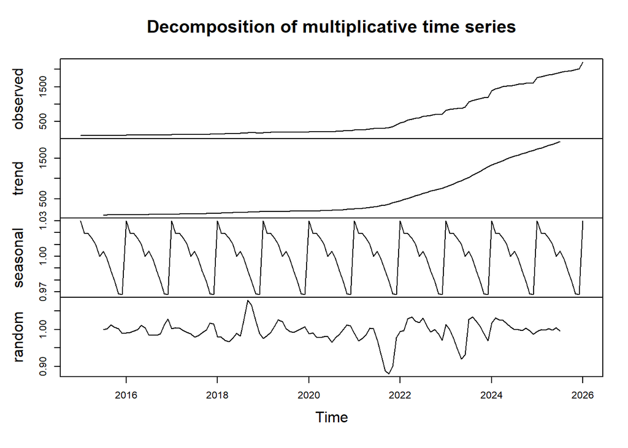

```r
decomp_mult <- decompose(ts_cci, type = "multiplicative")

plot(decomp_mult)
```

```r
trend_m    <- as.numeric(decomp_mult$trend)
seasonal_m <- as.numeric(decomp_mult$seasonal)

mult_fitted <- trend_m * seasonal_m
mult_errors <- as.numeric(ts_cci) - mult_fitted
mult_bias <- mean(mult_errors, na.rm = TRUE)
mult_mad  <- mean(abs(mult_errors), na.rm = TRUE)
mult_mse  <- mean(mult_errors^2, na.rm = TRUE)
mult_mape <- mean(abs(mult_errors / as.numeric(ts_cci)) * 100, na.rm = TRUE)
mult_rsfe <- sum(mult_errors, na.rm = TRUE)
mult_ts   <- mult_rsfe / mult_mad

cat("Multiplicative Decomposition:\n")
```

```
## Multiplicative Decomposition:
```

```r
cat("Bias:", round(mult_bias, 2), "| MAD:", round(mult_mad, 2),
    "| MSE:", round(mult_mse, 2), "| MAPE:", round(mult_mape, 2), "%\n")
```

```
## Bias: -1.6 | MAD: 8.97 | MSE: 267.66 | MAPE: 1.9 %
```

```r
cat("RSFE:", round(mult_rsfe, 2), "| Tracking Signal:", round(mult_ts, 2), "\n")
```

```
## RSFE: -193.91 | Tracking Signal: -21.62
```

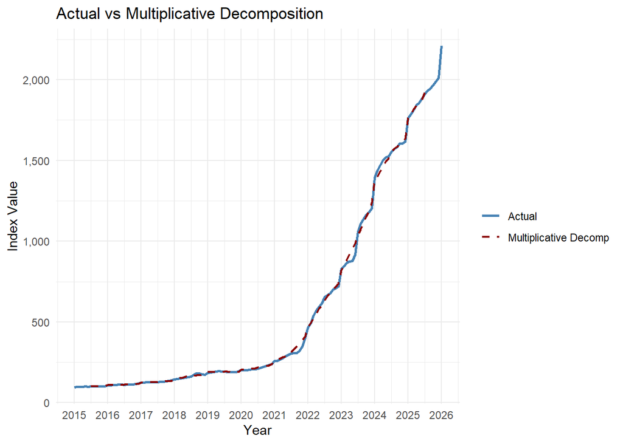

```r
mult_df <- data.frame(
  date   = as.numeric(time(ts_cci)),
  actual = as.numeric(ts_cci),
  fitted = mult_fitted
)

ggplot(mult_df, aes(x = date)) +
  geom_line(aes(y = actual, color = "Actual"), linewidth = 1) +
  geom_line(aes(y = fitted, color = "Multiplicative Decomp"),
            linewidth = 0.8, linetype = "dashed", na.rm = TRUE) +
  scale_color_manual(values = c("Actual" = "steelblue",
                                 "Multiplicative Decomp" = "darkred")) +
  labs(title = "Actual vs Multiplicative Decomposition",
       x = "Year", y = "Index Value", color = "") +
  theme_minimal() +
  scale_y_continuous(labels = comma) +
  scale_x_continuous(breaks = 2015:2026)
```

## 14. Regression with Trend and Seasonal Dummies

```r
n <- length(ts_cci)
t <- 1:n
months_factor <- as.factor(cycle(ts_cci))

reg_model <- lm(as.numeric(ts_cci) ~ t + months_factor)
summary(reg_model)
```

```
##
## Call:
## lm(formula = as.numeric(ts_cci) ~ t + months_factor)
##
## Residuals:
##     Min      1Q  Median      3Q     Max
## -474.59 -259.78  -26.81  284.21  632.01
##
## Coefficients:
##                  Estimate Std. Error t value Pr(>|t|)
## (Intercept)     -295.7430   103.8934  -2.847   0.0052 **
## t                 14.0900     0.7217  19.524   <2e-16 ***
## months_factor2   -60.8531   133.0172  -0.457   0.6482
## months_factor3   -62.1894   132.9996  -0.468   0.6409
## months_factor4   -65.1321   132.9859  -0.490   0.6252
## months_factor5   -71.3803   132.9761  -0.537   0.5924
## months_factor6   -76.1839   132.9702  -0.573   0.5678
## months_factor7   -67.3639   132.9682  -0.507   0.6134
## months_factor8   -70.5694   132.9702  -0.531   0.5966
## months_factor9   -77.3257   132.9761  -0.582   0.5620
## months_factor10  -81.0676   132.9859  -0.610   0.5433
## months_factor11  -87.7985   132.9996  -0.660   0.5104
## months_factor12  -89.8994   133.0172  -0.676   0.5004
## ---
## Signif. codes:  0 '***' 0.001 '**' 0.01 '*' 0.05 '.' 0.1 ' ' 1
##
## Residual standard error: 318.5 on 120 degrees of freedom
## Multiple R-squared:  0.7616, Adjusted R-squared:  0.7377
## F-statistic: 31.94 on 12 and 120 DF,  p-value: < 2.2e-16
```

```r
reg_fitted   <- as.numeric(fitted(reg_model))
reg_forecast <- predict(reg_model,
                         newdata = data.frame(t = n + 1,
                                              months_factor = factor(2,
                                              levels = levels(months_factor))))

reg_errors <- as.numeric(ts_cci) - reg_fitted
reg_bias <- mean(reg_errors)
reg_mad  <- mean(abs(reg_errors))
reg_mse  <- mean(reg_errors^2)
reg_mape <- mean(abs(reg_errors / as.numeric(ts_cci)) * 100)
reg_rsfe <- sum(reg_errors)
reg_ts   <- reg_rsfe / reg_mad

cat("Regression with Trend+Seasonal Forecast Feb 2026:",
    round(reg_forecast, 2), "\n")
```

```
## Regression with Trend+Seasonal Forecast Feb 2026: 1531.46
```

```r
cat("Bias:", round(reg_bias, 2), "| MAD:", round(reg_mad, 2),
    "| MSE:", round(reg_mse, 2), "| MAPE:", round(reg_mape, 2), "%\n")
```

```
## Bias: 0 | MAD: 265.79 | MSE: 91552.78 | MAPE: 107.57 %
```

```r
cat("RSFE:", round(reg_rsfe, 2), "| Tracking Signal:", round(reg_ts, 2), "\n")
```

```
## RSFE: 0 | Tracking Signal: 0
```

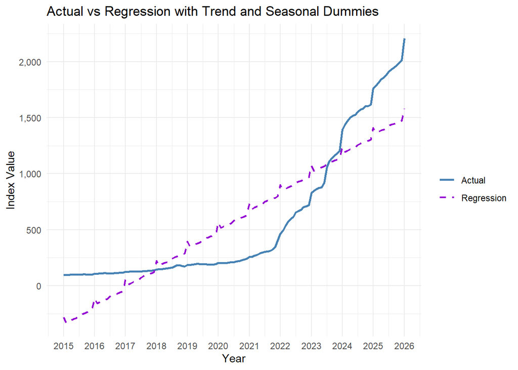

```r
reg_df <- data.frame(
  date   = as.numeric(time(ts_cci)),
  actual = as.numeric(ts_cci),
  fitted = reg_fitted
)

ggplot(reg_df, aes(x = date)) +
  geom_line(aes(y = actual, color = "Actual"), linewidth = 1) +
  geom_line(aes(y = fitted, color = "Regression"),
            linewidth = 0.8, linetype = "dashed") +
  scale_color_manual(values = c("Actual" = "steelblue",
                                 "Regression" = "darkviolet")) +
  labs(title = "Actual vs Regression with Trend and Seasonal Dummies",
       x = "Year", y = "Index Value", color = "") +
  theme_minimal() +
  scale_y_continuous(labels = comma) +
  scale_x_continuous(breaks = 2015:2026)
```

## 15. Forecast Accuracy Comparison

```r
library(knitr)

comparison <- data.frame(
  Method = c("Naive", "Moving Average (3)", "Weighted Moving Average",
             "Exponential Smoothing", "Trend-Adjusted ES (Holt)",
             "Linear Trend", "Seasonal Indices",
             "Additive Decomposition", "Multiplicative Decomposition",
             "Regression Trend+Seasonal"),
  Bias = round(c(naive_bias, ma_bias, wma_bias, es_bias, holt_bias,
                  trend_bias, NA, add_bias, mult_bias, reg_bias), 2),
  MAD  = round(c(naive_mad, ma_mad, wma_mad, es_mad, holt_mad,
                  trend_mad, NA, add_mad, mult_mad, reg_mad), 2),
  MSE  = round(c(naive_mse, ma_mse, wma_mse, es_mse, holt_mse,
                  trend_mse, NA, add_mse, mult_mse, reg_mse), 2),
  MAPE = round(c(naive_mape, ma_mape, wma_mape, es_mape, holt_mape,
                  trend_mape, NA, add_mape, mult_mape, reg_mape), 2),
  RSFE = round(c(naive_rsfe, ma_rsfe, wma_rsfe, es_rsfe, holt_rsfe,
                  trend_rsfe, NA, add_rsfe, mult_rsfe, reg_rsfe), 2),
  Tracking_Signal = round(c(naive_ts, ma_ts, wma_ts, es_ts, holt_ts,
                              trend_ts, NA, add_ts, mult_ts, reg_ts), 2),
  Next_Period_Forecast = round(c(naive_forecast, ma_forecast, wma_forecast,
                                  es_forecast, holt_forecast, trend_forecast,
                                  NA, NA, NA, reg_forecast), 2)
)

kable(comparison, caption = "Forecast Accuracy Comparison Table")
```

Forecast Accuracy Comparison Table

| Method | Bias | MAD | MSE | MAPE | RSFE | Tracking_Signal | Next_Period_Forecast |
| --- | --- | --- | --- | --- | --- | --- | --- |
| Naive | 16.01 | 16.27 | 1253.79 | 2.45 | 2113.11 | 129.87 | 2210.24 |
| Moving Average (3) | 15.62 | 15.83 | 889.04 | 2.38 | 2046.60 | 129.28 | 2070.19 |
| Weighted Moving Average | 7.91 | 8.02 | 251.47 | 1.20 | 1036.50 | 129.18 | 2128.53 |
| Exponential Smoothing | 17.48 | 17.74 | 1361.45 | 2.67 | 2325.33 | 131.05 | 2190.14 |
| Trend-Adjusted ES (Holt) | 1.86 | 12.29 | 885.62 | 1.82 | 247.88 | 20.17 | 2267.56 |
| Linear Trend | 0.00 | 265.31 | 92076.66 | 107.24 | 0.00 | 0.00 | 1524.21 |
| Seasonal Indices | NA | NA | NA | NA | NA | NA | NA |
| Additive Decomposition | -1.16 | 15.44 | 433.04 | 4.98 | -139.79 | -9.05 | NA |
| Multiplicative Decomposition | -1.60 | 8.97 | 267.66 | 1.90 | -193.91 | -21.62 | NA |
| Regression Trend+Seasonal | 0.00 | 265.79 | 91552.78 | 107.57 | 0.00 | 0.00 | 1531.46 |